# PROJECT TITLE: WRANGLING, ANALYSING, VISUALIZING AND COMMUNICATING INSIGHTS OF DATA GOTTEN FROM FORD GOBIKE SYSTEM DATA

Table of Contents

> INTRODUCTION

> GATHERING DATA

> DATA ASSESSMENT

> DATA CLEANING

> DATA WRANGLING AND VISUALIZATION

> SUMMARY

# PROBLEM DEFINITION

> Wrangling and Analyzing, Visualizing and communicating insights of data gotten from ford gobike system data

> This notebook looks into using python-based analytics and data wrangling in an attempt to get insights on the dataset curated for this project.

# DATA

> The dataset used for this project came from [here](https://video.udacity-data.com/topher/2020/October/5f91cf38_201902-fordgobike-tripdata/201902-fordgobike-tripdata.csv)

# FEATURES

> The features of the data set used for this project included information about individual rides made in a bike-sharing system covering the greater San Francisco Bay area. Some of the oinformation includes
> - Latitude
> - Longitude
> - Member birth year
> - Duration seconds
> - Start time
> - End time
> - Start station id
> - End station id
> - Bike ID et.c

# QUESTIONS

- Which gender commonly ride bike
- Is age of bikers dependent on how long they can ride?
- When are most trips taken in terms of time of day?
- How often do suscribers ride bikes?
- Is gender of users dependent on Duration of time that users travelled?

```python
import pandas as pd
import numpy as np
import matplotlib.pyplot as plt
import seaborn as sns
%matplotlib inline
import datetime as dt
```

# GATHERING DATA

```python
# import data
df= pd.read_csv('201902-fordgobike-tripdata.csv')
df.head()
```

|  | duration_sec | start_time | end_time | start_station_id | start_station_name | start_station_latitude | start_station_longitude | end_station_id | end_station_name | end_station_latitude | end_station_longitude | bike_id | user_type | member_birth_year | member_gender | bike_share_for_all_trip |
| --- | --- | --- | --- | --- | --- | --- | --- | --- | --- | --- | --- | --- | --- | --- | --- | --- |
| 0 | 52185 | 2019-02-28 17:32:10.1450 | 2019-03-01 08:01:55.9750 | 21.0 | Montgomery St BART Station (Market St at 2nd St) | 37.789625 | -122.400811 | 13.0 | Commercial St at Montgomery St | 37.794231 | -122.402923 | 4902 | Customer | 1984.0 | Male | No |
| 1 | 42521 | 2019-02-28 18:53:21.7890 | 2019-03-01 06:42:03.0560 | 23.0 | The Embarcadero at Steuart St | 37.791464 | -122.391034 | 81.0 | Berry St at 4th St | 37.775880 | -122.393170 | 2535 | Customer | NaN | NaN | No |
| 2 | 61854 | 2019-02-28 12:13:13.2180 | 2019-03-01 05:24:08.1460 | 86.0 | Market St at Dolores St | 37.769305 | -122.426826 | 3.0 | Powell St BART Station (Market St at 4th St) | 37.786375 | -122.404904 | 5905 | Customer | 1972.0 | Male | No |
| 3 | 36490 | 2019-02-28 17:54:26.0100 | 2019-03-01 04:02:36.8420 | 375.0 | Grove St at Masonic Ave | 37.774836 | -122.446546 | 70.0 | Central Ave at Fell St | 37.773311 | -122.444293 | 6638 | Subscriber | 1989.0 | Other | No |
| 4 | 1585 | 2019-02-28 23:54:18.5490 | 2019-03-01 00:20:44.0740 | 7.0 | Frank H Ogawa Plaza | 37.804562 | -122.271738 | 222.0 | 10th Ave at E 15th St | 37.792714 | -122.248780 | 4898 | Subscriber | 1974.0 | Male | Yes |

# ASSESSING DATA

```python
df.info()
```

```
<class 'pandas.core.frame.DataFrame'>
RangeIndex: 183412 entries, 0 to 183411
Data columns (total 16 columns):
 #   Column                   Non-Null Count   Dtype
---  ------                   --------------   -----
 0   duration_sec             183412 non-null  int64
 1   start_time               183412 non-null  object
 2   end_time                 183412 non-null  object
 3   start_station_id         183215 non-null  float64
 4   start_station_name       183215 non-null  object
 5   start_station_latitude   183412 non-null  float64
 6   start_station_longitude  183412 non-null  float64
 7   end_station_id           183215 non-null  float64
 8   end_station_name         183215 non-null  object
 9   end_station_latitude     183412 non-null  float64
 10  end_station_longitude    183412 non-null  float64
 11  bike_id                  183412 non-null  int64
 12  user_type                183412 non-null  object
 13  member_birth_year        175147 non-null  float64
 14  member_gender            175147 non-null  object
 15  bike_share_for_all_trip  183412 non-null  object
dtypes: float64(7), int64(2), object(7)
memory usage: 22.4+ MB
```

```python
# year is in float form instead of int format
# end station should be in int
```

```python
df.shape
```

```
(183412, 16)
```

```python
df.sample(10)
```

|  | duration_sec | start_time | end_time | start_station_id | start_station_name | start_station_latitude | start_station_longitude | end_station_id | end_station_name | end_station_latitude | end_station_longitude | bike_id | user_type | member_birth_year | member_gender | bike_share_for_all_trip |
| --- | --- | --- | --- | --- | --- | --- | --- | --- | --- | --- | --- | --- | --- | --- | --- | --- |
| 90381 | 269 | 2019-02-16 12:52:25.8540 | 2019-02-16 12:56:55.7990 | 58.0 | Market St at 10th St | 37.776619 | -122.417385 | 5.0 | Powell St BART Station (Market St at 5th St) | 37.783899 | -122.408445 | 4877 | Subscriber | 1972.0 | Male | Yes |
| 74722 | 703 | 2019-02-19 09:46:40.4980 | 2019-02-19 09:58:24.4740 | 246.0 | Berkeley Civic Center | 37.869060 | -122.270556 | 238.0 | MLK Jr Way at University Ave | 37.871719 | -122.273068 | 6431 | Subscriber | 1977.0 | Male | Yes |
| 128549 | 313 | 2019-02-10 13:03:29.5950 | 2019-02-10 13:08:42.7990 | 44.0 | Civic Center/UN Plaza BART Station (Market St ... | 37.781074 | -122.411738 | 60.0 | 8th St at Ringold St | 37.774520 | -122.409449 | 4384 | Subscriber | 1974.0 | Male | Yes |
| 167974 | 118 | 2019-02-04 16:36:27.1590 | 2019-02-04 16:38:25.4880 | 243.0 | Bancroft Way at College Ave | 37.869360 | -122.254337 | 239.0 | Bancroft Way at Telegraph Ave | 37.868813 | -122.258764 | 3316 | Subscriber | 1992.0 | Male | No |
| 86612 | 1361 | 2019-02-17 12:09:04.0690 | 2019-02-17 12:31:45.1160 | 21.0 | Montgomery St BART Station (Market St at 2nd St) | 37.789625 | -122.400811 | 336.0 | Potrero Ave and Mariposa St | 37.763281 | -122.407377 | 5946 | Customer | 1989.0 | Male | No |
| 139001 | 264 | 2019-02-07 23:27:54.4210 | 2019-02-07 23:32:19.2590 | 3.0 | Powell St BART Station (Market St at 4th St) | 37.786375 | -122.404904 | 10.0 | Washington St at Kearny St | 37.795393 | -122.404770 | 1985 | Subscriber | 1994.0 | Male | No |
| 53514 | 738 | 2019-02-21 15:28:41.7040 | 2019-02-21 15:40:59.7360 | 20.0 | Mechanics Monument Plaza (Market St at Bush St) | 37.791300 | -122.399051 | 80.0 | Townsend St at 5th St | 37.775235 | -122.397437 | 6072 | Subscriber | 1988.0 | Male | No |
| 171104 | 400 | 2019-02-04 06:28:54.1860 | 2019-02-04 06:35:34.4810 | 119.0 | 18th St at Noe St | 37.761047 | -122.432642 | 223.0 | 16th St Mission BART Station 2 | 37.764765 | -122.420091 | 5030 | Subscriber | 1978.0 | Male | No |
| 9366 | 870 | 2019-02-28 07:15:06.4230 | 2019-02-28 07:29:37.0490 | 119.0 | 18th St at Noe St | 37.761047 | -122.432642 | 67.0 | San Francisco Caltrain Station 2 (Townsend St... | 37.776639 | -122.395526 | 5222 | Subscriber | 1969.0 | Male | No |
| 80006 | 246 | 2019-02-18 16:32:04.1650 | 2019-02-18 16:36:10.3120 | 16.0 | Steuart St at Market St | 37.794130 | -122.394430 | 25.0 | Howard St at 2nd St | 37.787522 | -122.397405 | 6489 | Subscriber | 1980.0 | Male | No |

```python
df.info()
```

```
<class 'pandas.core.frame.DataFrame'>
RangeIndex: 183412 entries, 0 to 183411
Data columns (total 16 columns):
 #   Column                   Non-Null Count   Dtype
---  ------                   --------------   -----
 0   duration_sec             183412 non-null  int64
 1   start_time               183412 non-null  object
 2   end_time                 183412 non-null  object
 3   start_station_id         183215 non-null  float64
 4   start_station_name       183215 non-null  object
 5   start_station_latitude   183412 non-null  float64
 6   start_station_longitude  183412 non-null  float64
 7   end_station_id           183215 non-null  float64
 8   end_station_name         183215 non-null  object
 9   end_station_latitude     183412 non-null  float64
 10  end_station_longitude    183412 non-null  float64
 11  bike_id                  183412 non-null  int64
 12  user_type                183412 non-null  object
 13  member_birth_year        175147 non-null  float64
 14  member_gender            175147 non-null  object
 15  bike_share_for_all_trip  183412 non-null  object
dtypes: float64(7), int64(2), object(7)
memory usage: 22.4+ MB
```

```python
# Start time and end time should be in datetime
# there are missing values
```

```python
# Check for duplicated values
df[df.bike_id.duplicated()]
```

|  | duration_sec | start_time | end_time | start_station_id | start_station_name | start_station_latitude | start_station_longitude | end_station_id | end_station_name | end_station_latitude | end_station_longitude | bike_id | user_type | member_birth_year | member_gender | bike_share_for_all_trip |
| --- | --- | --- | --- | --- | --- | --- | --- | --- | --- | --- | --- | --- | --- | --- | --- | --- |
| 41 | 346 | 2019-02-28 23:40:56.0750 | 2019-02-28 23:46:42.4830 | 10.0 | Washington St at Kearny St | 37.795393 | -122.404770 | 19.0 | Post St at Kearny St | 37.788975 | -122.403452 | 6488 | Subscriber | 1992.0 | Male | No |
| 51 | 532 | 2019-02-28 23:30:37.9410 | 2019-02-28 23:39:30.2060 | 28.0 | The Embarcadero at Bryant St | 37.787168 | -122.388098 | 349.0 | Howard St at Mary St | 37.781010 | -122.405666 | 6361 | Customer | 1984.0 | Male | No |
| 62 | 325 | 2019-02-28 23:27:40.7690 | 2019-02-28 23:33:06.0440 | 36.0 | Folsom St at 3rd St | 37.783830 | -122.398870 | 10.0 | Washington St at Kearny St | 37.795393 | -122.404770 | 6329 | Subscriber | 1967.0 | Male | Yes |
| 81 | 294 | 2019-02-28 23:15:21.1130 | 2019-02-28 23:20:15.7980 | 356.0 | Valencia St at Clinton Park | 37.769188 | -122.422285 | 58.0 | Market St at 10th St | 37.776619 | -122.417385 | 5938 | Subscriber | 1992.0 | Female | No |
| 87 | 2151 | 2019-02-28 22:42:05.2150 | 2019-02-28 23:17:56.9670 | 78.0 | Folsom St at 9th St | 37.773717 | -122.411647 | 15.0 | San Francisco Ferry Building (Harry Bridges Pl... | 37.795392 | -122.394203 | 5411 | Subscriber | 1972.0 | Male | No |
| ... | ... | ... | ... | ... | ... | ... | ... | ... | ... | ... | ... | ... | ... | ... | ... | ... |
| 183407 | 480 | 2019-02-01 00:04:49.7240 | 2019-02-01 00:12:50.0340 | 27.0 | Beale St at Harrison St | 37.788059 | -122.391865 | 324.0 | Union Square (Powell St at Post St) | 37.788300 | -122.408531 | 4832 | Subscriber | 1996.0 | Male | No |
| 183408 | 313 | 2019-02-01 00:05:34.7440 | 2019-02-01 00:10:48.5020 | 21.0 | Montgomery St BART Station (Market St at 2nd St) | 37.789625 | -122.400811 | 66.0 | 3rd St at Townsend St | 37.778742 | -122.392741 | 4960 | Subscriber | 1984.0 | Male | No |
| 183409 | 141 | 2019-02-01 00:06:05.5490 | 2019-02-01 00:08:27.2200 | 278.0 | The Alameda at Bush St | 37.331932 | -121.904888 | 277.0 | Morrison Ave at Julian St | 37.333658 | -121.908586 | 3824 | Subscriber | 1990.0 | Male | Yes |
| 183410 | 139 | 2019-02-01 00:05:34.3600 | 2019-02-01 00:07:54.2870 | 220.0 | San Pablo Ave at MLK Jr Way | 37.811351 | -122.273422 | 216.0 | San Pablo Ave at 27th St | 37.817827 | -122.275698 | 5095 | Subscriber | 1988.0 | Male | No |
| 183411 | 271 | 2019-02-01 00:00:20.6360 | 2019-02-01 00:04:52.0580 | 24.0 | Spear St at Folsom St | 37.789677 | -122.390428 | 37.0 | 2nd St at Folsom St | 37.785000 | -122.395936 | 1057 | Subscriber | 1989.0 | Male | No |

178766 rows × 16 columns

```python
df[df.bike_id==4960]
```

|  | duration_sec | start_time | end_time | start_station_id | start_station_name | start_station_latitude | start_station_longitude | end_station_id | end_station_name | end_station_latitude | end_station_longitude | bike_id | user_type | member_birth_year | member_gender | bike_share_for_all_trip |
| --- | --- | --- | --- | --- | --- | --- | --- | --- | --- | --- | --- | --- | --- | --- | --- | --- |
| 170 | 260 | 2019-02-28 22:38:36.7820 | 2019-02-28 22:42:56.8560 | 62.0 | Victoria Manalo Draves Park | 37.777791 | -122.406432 | 36.0 | Folsom St at 3rd St | 37.783830 | -122.398870 | 4960 | Subscriber | 1994.0 | Male | No |
| 530 | 309 | 2019-02-28 21:10:53.0230 | 2019-02-28 21:16:02.7160 | 58.0 | Market St at 10th St | 37.776619 | -122.417385 | 62.0 | Victoria Manalo Draves Park | 37.777791 | -122.406432 | 4960 | Subscriber | 1994.0 | Male | No |
| 2796 | 790 | 2019-02-28 17:42:44.9450 | 2019-02-28 17:55:55.3250 | 66.0 | 3rd St at Townsend St | 37.778742 | -122.392741 | 58.0 | Market St at 10th St | 37.776619 | -122.417385 | 4960 | Subscriber | 1980.0 | Male | No |
| 7657 | 741 | 2019-02-28 08:50:05.7400 | 2019-02-28 09:02:27.3770 | 42.0 | San Francisco City Hall (Polk St at Grove St) | 37.778650 | -122.418230 | 66.0 | 3rd St at Townsend St | 37.778742 | -122.392741 | 4960 | Subscriber | 1994.0 | Male | No |
| 8901 | 879 | 2019-02-28 07:51:07.9500 | 2019-02-28 08:05:47.2810 | 81.0 | Berry St at 4th St | 37.775880 | -122.393170 | 42.0 | San Francisco City Hall (Polk St at Grove St) | 37.778650 | -122.418230 | 4960 | Subscriber | 1984.0 | Female | No |
| ... | ... | ... | ... | ... | ... | ... | ... | ... | ... | ... | ... | ... | ... | ... | ... | ... |
| 182678 | 1604 | 2019-02-01 07:38:37.0290 | 2019-02-01 08:05:21.4310 | 10.0 | Washington St at Kearny St | 37.795393 | -122.404770 | 373.0 | Potrero del Sol Park (25th St at Utah St) | 37.751792 | -122.405216 | 4960 | Subscriber | 1985.0 | Male | No |
| 183289 | 770 | 2019-02-01 05:27:16.4650 | 2019-02-01 05:40:07.2340 | 67.0 | San Francisco Caltrain Station 2 (Townsend St... | 37.776639 | -122.395526 | 10.0 | Washington St at Kearny St | 37.795393 | -122.404770 | 4960 | Subscriber | 1959.0 | Male | No |
| 183378 | 659 | 2019-02-01 00:53:36.1430 | 2019-02-01 01:04:35.3710 | 47.0 | 4th St at Harrison St | 37.780955 | -122.399749 | 67.0 | San Francisco Caltrain Station 2 (Townsend St... | 37.776639 | -122.395526 | 4960 | Subscriber | 1985.0 | Other | No |
| 183389 | 184 | 2019-02-01 00:43:56.5560 | 2019-02-01 00:47:01.0090 | 66.0 | 3rd St at Townsend St | 37.778742 | -122.392741 | 47.0 | 4th St at Harrison St | 37.780955 | -122.399749 | 4960 | Subscriber | 1985.0 | Other | No |
| 183408 | 313 | 2019-02-01 00:05:34.7440 | 2019-02-01 00:10:48.5020 | 21.0 | Montgomery St BART Station (Market St at 2nd St) | 37.789625 | -122.400811 | 66.0 | 3rd St at Townsend St | 37.778742 | -122.392741 | 4960 | Subscriber | 1984.0 | Male | No |

132 rows × 16 columns

```python
df[df.bike_id==6488]
```

|  | duration_sec | start_time | end_time | start_station_id | start_station_name | start_station_latitude | start_station_longitude | end_station_id | end_station_name | end_station_latitude | end_station_longitude | bike_id | user_type | member_birth_year | member_gender | bike_share_for_all_trip |
| --- | --- | --- | --- | --- | --- | --- | --- | --- | --- | --- | --- | --- | --- | --- | --- | --- |
| 9 | 1049 | 2019-02-28 23:49:47.6990 | 2019-03-01 00:07:17.0250 | 19.0 | Post St at Kearny St | 37.788975 | -122.403452 | 121.0 | Mission Playground | 37.759210 | -122.421339 | 6488 | Subscriber | 1992.0 | Male | No |
| 41 | 346 | 2019-02-28 23:40:56.0750 | 2019-02-28 23:46:42.4830 | 10.0 | Washington St at Kearny St | 37.795393 | -122.404770 | 19.0 | Post St at Kearny St | 37.788975 | -122.403452 | 6488 | Subscriber | 1992.0 | Male | No |
| 3325 | 658 | 2019-02-28 17:18:14.8670 | 2019-02-28 17:29:13.6860 | 58.0 | Market St at 10th St | 37.776619 | -122.417385 | 10.0 | Washington St at Kearny St | 37.795393 | -122.404770 | 6488 | Subscriber | 1993.0 | Male | No |
| 3794 | 408 | 2019-02-28 16:56:35.4470 | 2019-02-28 17:03:24.1420 | 5.0 | Powell St BART Station (Market St at 5th St) | 37.783899 | -122.408445 | 58.0 | Market St at 10th St | 37.776619 | -122.417385 | 6488 | Subscriber | 1998.0 | Male | No |
| 3948 | 244 | 2019-02-28 16:46:39.9490 | 2019-02-28 16:50:44.2300 | 33.0 | Golden Gate Ave at Hyde St | 37.781650 | -122.415408 | 5.0 | Powell St BART Station (Market St at 5th St) | 37.783899 | -122.408445 | 6488 | Subscriber | 1987.0 | Male | No |
| ... | ... | ... | ... | ... | ... | ... | ... | ... | ... | ... | ... | ... | ... | ... | ... | ... |
| 104400 | 285 | 2019-02-14 08:38:30.8850 | 2019-02-14 08:43:16.1440 | 78.0 | Folsom St at 9th St | 37.773717 | -122.411647 | 43.0 | San Francisco Public Library (Grove St at Hyde... | 37.778768 | -122.415929 | 6488 | Subscriber | 1990.0 | Female | No |
| 104614 | 233 | 2019-02-14 08:24:17.9430 | 2019-02-14 08:28:11.4580 | 43.0 | San Francisco Public Library (Grove St at Hyde... | 37.778768 | -122.415929 | 78.0 | Folsom St at 9th St | 37.773717 | -122.411647 | 6488 | Subscriber | 1992.0 | Male | Yes |
| 104771 | 227 | 2019-02-14 08:12:27.5120 | 2019-02-14 08:16:15.0110 | 59.0 | S Van Ness Ave at Market St | 37.774814 | -122.418954 | 43.0 | San Francisco Public Library (Grove St at Hyde... | 37.778768 | -122.415929 | 6488 | Subscriber | 1985.0 | Male | No |
| 105102 | 429 | 2019-02-14 07:42:30.5180 | 2019-02-14 07:49:40.2550 | 90.0 | Townsend St at 7th St | 37.771058 | -122.402717 | 59.0 | S Van Ness Ave at Market St | 37.774814 | -122.418954 | 6488 | Subscriber | 1983.0 | Male | No |
| 105190 | 424 | 2019-02-14 07:32:09.4130 | 2019-02-14 07:39:13.7950 | 98.0 | Valencia St at 16th St | 37.765052 | -122.421866 | 90.0 | Townsend St at 7th St | 37.771058 | -122.402717 | 6488 | Subscriber | 1990.0 | Male | No |

87 rows × 16 columns

```python
# After research, I concluded that since the bikes are for rentage, multiple people can rent the same bike at different time
# convert year,start_time,end_time to datetime
def convert_datetimes(dataframe, column):
    dataframe[column]= pd.to_datetime(dataframe[column])

convert_datetimes(df, 'start_time')
convert_datetimes(df, 'end_time')

df.info()
```

```
<class 'pandas.core.frame.DataFrame'>
RangeIndex: 183412 entries, 0 to 183411
Data columns (total 16 columns):
 #   Column                   Non-Null Count   Dtype
---  ------                   --------------   -----
 0   duration_sec             183412 non-null  int64
 1   start_time               183412 non-null  datetime64[ns]
 2   end_time                 183412 non-null  datetime64[ns]
 3   start_station_id         183215 non-null  float64
 4   start_station_name       183215 non-null  object
 5   start_station_latitude   183412 non-null  float64
 6   start_station_longitude  183412 non-null  float64
 7   end_station_id           183215 non-null  float64
 8   end_station_name         183215 non-null  object
 9   end_station_latitude     183412 non-null  float64
 10  end_station_longitude    183412 non-null  float64
 11  bike_id                  183412 non-null  int64
 12  user_type                183412 non-null  object
 13  member_birth_year        175147 non-null  float64
 14  member_gender            175147 non-null  object
 15  bike_share_for_all_trip  183412 non-null  object
dtypes: datetime64[ns](2), float64(7), int64(2), object(5)
memory usage: 22.4+ MB
```

```python
# Check for missing values
df[df['member_birth_year'].isna()]
```

|  | duration_sec | start_time | end_time | start_station_id | start_station_name | start_station_latitude | start_station_longitude | end_station_id | end_station_name | end_station_latitude | end_station_longitude | bike_id | user_type | member_birth_year | member_gender | bike_share_for_all_trip |
| --- | --- | --- | --- | --- | --- | --- | --- | --- | --- | --- | --- | --- | --- | --- | --- | --- |
| 1 | 42521 | 2019-02-28 18:53:21.789 | 2019-03-01 06:42:03.056 | 23.0 | The Embarcadero at Steuart St | 37.791464 | -122.391034 | 81.0 | Berry St at 4th St | 37.775880 | -122.393170 | 2535 | Customer | NaN | NaN | No |
| 13 | 915 | 2019-02-28 23:49:06.062 | 2019-03-01 00:04:21.867 | 252.0 | Channing Way at Shattuck Ave | 37.865847 | -122.267443 | 244.0 | Shattuck Ave at Hearst Ave | 37.873676 | -122.268487 | 5101 | Subscriber | NaN | NaN | No |
| 28 | 650 | 2019-02-28 23:43:27.503 | 2019-02-28 23:54:18.451 | 258.0 | University Ave at Oxford St | 37.872355 | -122.266447 | 263.0 | Channing Way at San Pablo Ave | 37.862827 | -122.290231 | 4784 | Customer | NaN | NaN | No |
| 53 | 3418 | 2019-02-28 22:41:16.362 | 2019-02-28 23:38:14.363 | 11.0 | Davis St at Jackson St | 37.797280 | -122.398436 | 11.0 | Davis St at Jackson St | 37.797280 | -122.398436 | 319 | Customer | NaN | NaN | No |
| 65 | 926 | 2019-02-28 23:17:05.853 | 2019-02-28 23:32:32.682 | 13.0 | Commercial St at Montgomery St | 37.794231 | -122.402923 | 81.0 | Berry St at 4th St | 37.775880 | -122.393170 | 2951 | Subscriber | NaN | NaN | No |
| ... | ... | ... | ... | ... | ... | ... | ... | ... | ... | ... | ... | ... | ... | ... | ... | ... |
| 183354 | 449 | 2019-02-01 01:35:07.663 | 2019-02-01 01:42:36.878 | 244.0 | Shattuck Ave at Hearst Ave | 37.873676 | -122.268487 | 253.0 | Haste St at College Ave | 37.866418 | -122.253799 | 5430 | Customer | NaN | NaN | No |
| 183356 | 795 | 2019-02-01 01:25:50.366 | 2019-02-01 01:39:05.950 | 368.0 | Myrtle St at Polk St | 37.785434 | -122.419622 | 125.0 | 20th St at Bryant St | 37.759200 | -122.409851 | 5400 | Subscriber | NaN | NaN | No |
| 183363 | 673 | 2019-02-01 01:12:24.420 | 2019-02-01 01:23:37.645 | 75.0 | Market St at Franklin St | 37.773793 | -122.421239 | 133.0 | Valencia St at 22nd St | 37.755213 | -122.420975 | 5166 | Customer | NaN | NaN | No |
| 183371 | 196 | 2019-02-01 01:08:38.641 | 2019-02-01 01:11:54.949 | 58.0 | Market St at 10th St | 37.776619 | -122.417385 | 75.0 | Market St at Franklin St | 37.773793 | -122.421239 | 2395 | Customer | NaN | NaN | No |
| 183402 | 122 | 2019-02-01 00:17:32.258 | 2019-02-01 00:19:34.938 | 119.0 | 18th St at Noe St | 37.761047 | -122.432642 | 120.0 | Mission Dolores Park | 37.761420 | -122.426435 | 4326 | Subscriber | NaN | NaN | No |

8265 rows × 16 columns

```python
len(df[df['member_birth_year'].isna()])
```

```
8265
```

```python
df.member_birth_year.value_counts()
```

```
1988.0    10236
1993.0     9325
1989.0     8972
1990.0     8658
1991.0     8498
          ...
1928.0        1
1878.0        1
1930.0        1
1910.0        1
1927.0        1
Name: member_birth_year, Length: 75, dtype: int64
```

```python
df.describe()
```

|  | duration_sec | start_station_id | start_station_latitude | start_station_longitude | end_station_id | end_station_latitude | end_station_longitude | bike_id | member_birth_year |
| --- | --- | --- | --- | --- | --- | --- | --- | --- | --- |
| count | 183412.000000 | 183215.000000 | 183412.000000 | 183412.000000 | 183215.000000 | 183412.000000 | 183412.000000 | 183412.000000 | 175147.000000 |
| mean | 726.078435 | 138.590427 | 37.771223 | -122.352664 | 136.249123 | 37.771427 | -122.352250 | 4472.906375 | 1984.806437 |
| std | 1794.389780 | 111.778864 | 0.099581 | 0.117097 | 111.515131 | 0.099490 | 0.116673 | 1664.383394 | 10.116689 |
| min | 61.000000 | 3.000000 | 37.317298 | -122.453704 | 3.000000 | 37.317298 | -122.453704 | 11.000000 | 1878.000000 |
| 25% | 325.000000 | 47.000000 | 37.770083 | -122.412408 | 44.000000 | 37.770407 | -122.411726 | 3777.000000 | 1980.000000 |
| 50% | 514.000000 | 104.000000 | 37.780760 | -122.398285 | 100.000000 | 37.781010 | -122.398279 | 4958.000000 | 1987.000000 |
| 75% | 796.000000 | 239.000000 | 37.797280 | -122.286533 | 235.000000 | 37.797320 | -122.288045 | 5502.000000 | 1992.000000 |
| max | 85444.000000 | 398.000000 | 37.880222 | -121.874119 | 398.000000 | 37.880222 | -121.874119 | 6645.000000 | 2001.000000 |

```python
# There are absurd birth years, e.g 1878-1930. it is not possible for people that are over or almost 100years to still be riding bike
```

```python
df.isna().sum()
```

```
duration_sec                  0
start_time                    0
end_time                      0
start_station_id            197
start_station_name          197
start_station_latitude        0
start_station_longitude       0
end_station_id              197
end_station_name            197
end_station_latitude          0
end_station_longitude         0
bike_id                       0
user_type                     0
member_birth_year          8265
member_gender              8265
bike_share_for_all_trip       0
dtype: int64
```

```python
new_df= df.dropna()
```

```python
len(new_df)
```

```
174952
```

```python
new_df.info()
```

```
<class 'pandas.core.frame.DataFrame'>
Int64Index: 174952 entries, 0 to 183411
Data columns (total 16 columns):
 #   Column                   Non-Null Count   Dtype
---  ------                   --------------   -----
 0   duration_sec             174952 non-null  int64
 1   start_time               174952 non-null  datetime64[ns]
 2   end_time                 174952 non-null  datetime64[ns]
 3   start_station_id         174952 non-null  float64
 4   start_station_name       174952 non-null  object
 5   start_station_latitude   174952 non-null  float64
 6   start_station_longitude  174952 non-null  float64
 7   end_station_id           174952 non-null  float64
 8   end_station_name         174952 non-null  object
 9   end_station_latitude     174952 non-null  float64
 10  end_station_longitude    174952 non-null  float64
 11  bike_id                  174952 non-null  int64
 12  user_type                174952 non-null  object
 13  member_birth_year        174952 non-null  float64
 14  member_gender            174952 non-null  object
 15  bike_share_for_all_trip  174952 non-null  object
dtypes: datetime64[ns](2), float64(7), int64(2), object(5)
memory usage: 22.7+ MB
```

# DATA CLEANING

```python
# convert_to_int function
def convert_to_int(df, column):
    df[column]= df[column].astype(int)
```

```python
# convert member birth year to int
convert_to_int(new_df,'member_birth_year')
```

```python
new_df.info()
```

```
<class 'pandas.core.frame.DataFrame'>
Int64Index: 174952 entries, 0 to 183411
Data columns (total 16 columns):
 #   Column                   Non-Null Count   Dtype
---  ------                   --------------   -----
 0   duration_sec             174952 non-null  int64
 1   start_time               174952 non-null  datetime64[ns]
 2   end_time                 174952 non-null  datetime64[ns]
 3   start_station_id         174952 non-null  float64
 4   start_station_name       174952 non-null  object
 5   start_station_latitude   174952 non-null  float64
 6   start_station_longitude  174952 non-null  float64
 7   end_station_id           174952 non-null  float64
 8   end_station_name         174952 non-null  object
 9   end_station_latitude     174952 non-null  float64
 10  end_station_longitude    174952 non-null  float64
 11  bike_id                  174952 non-null  int64
 12  user_type                174952 non-null  object
 13  member_birth_year        174952 non-null  int32
 14  member_gender            174952 non-null  object
 15  bike_share_for_all_trip  174952 non-null  object
dtypes: datetime64[ns](2), float64(6), int32(1), int64(2), object(5)
memory usage: 22.0+ MB
```

```python
new_df.start_station_id.value_counts()
```

```
58.0     3649
67.0     3408
81.0     2952
21.0     2711
3.0      2620
         ...
234.0       9
51.0        7
224.0       4
300.0       3
344.0       2
Name: start_station_id, Length: 329, dtype: int64
```

```python
# Convert start_station_id and end_station_id to int
convert_to_int(new_df, 'start_station_id')
convert_to_int(new_df, 'end_station_id')
```

```python
new_df.info()
```

```
<class 'pandas.core.frame.DataFrame'>
Int64Index: 174952 entries, 0 to 183411
Data columns (total 16 columns):
 #   Column                   Non-Null Count   Dtype
---  ------                   --------------   -----
 0   duration_sec             174952 non-null  int64
 1   start_time               174952 non-null  datetime64[ns]
 2   end_time                 174952 non-null  datetime64[ns]
 3   start_station_id         174952 non-null  int32
 4   start_station_name       174952 non-null  object
 5   start_station_latitude   174952 non-null  float64
 6   start_station_longitude  174952 non-null  float64
 7   end_station_id           174952 non-null  int32
 8   end_station_name         174952 non-null  object
 9   end_station_latitude     174952 non-null  float64
 10  end_station_longitude    174952 non-null  float64
 11  bike_id                  174952 non-null  int64
 12  user_type                174952 non-null  object
 13  member_birth_year        174952 non-null  int32
 14  member_gender            174952 non-null  object
 15  bike_share_for_all_trip  174952 non-null  object
dtypes: datetime64[ns](2), float64(4), int32(3), int64(2), object(5)
memory usage: 20.7+ MB
```

```python
new_df.start_station_name.value_counts()
```

```
Market St at 10th St                                         3649
San Francisco Caltrain Station 2  (Townsend St at 4th St)    3408
Berry St at 4th St                                           2952
Montgomery St BART Station (Market St at 2nd St)             2711
Powell St BART Station (Market St at 4th St)                 2620
                                                             ...
Farnam St at Fruitvale Ave                                      9
Parker Ave at McAllister St                                     7
21st Ave at International Blvd                                  4
Palm St at Willow St                                            3
16th St Depot                                                   2
Name: start_station_name, Length: 329, dtype: int64
```

```python
new_df['member_gender'].value_counts()
```

```
Male      130500
Female     40805
Other       3647
Name: member_gender, dtype: int64
```

```python
new_df.user_type.value_counts()
```

```
Subscriber    158386
Customer       16566
Name: user_type, dtype: int64
```

```python
# Convert user type and member_gender to categorical
# convert_to_categorical function
def convert_to_categorical(df, column):
    df[column]= pd.Categorical(df[column])
```

```python
convert_to_categorical(new_df, 'member_gender')
convert_to_categorical(new_df, 'user_type')
```

```python
new_df.info()
```

```
<class 'pandas.core.frame.DataFrame'>
Int64Index: 174952 entries, 0 to 183411
Data columns (total 16 columns):
 #   Column                   Non-Null Count   Dtype
---  ------                   --------------   -----
 0   duration_sec             174952 non-null  int64
 1   start_time               174952 non-null  datetime64[ns]
 2   end_time                 174952 non-null  datetime64[ns]
 3   start_station_id         174952 non-null  int32
 4   start_station_name       174952 non-null  object
 5   start_station_latitude   174952 non-null  float64
 6   start_station_longitude  174952 non-null  float64
 7   end_station_id           174952 non-null  int32
 8   end_station_name         174952 non-null  object
 9   end_station_latitude     174952 non-null  float64
 10  end_station_longitude    174952 non-null  float64
 11  bike_id                  174952 non-null  int64
 12  user_type                174952 non-null  category
 13  member_birth_year        174952 non-null  int32
 14  member_gender            174952 non-null  category
 15  bike_share_for_all_trip  174952 non-null  object
dtypes: category(2), datetime64[ns](2), float64(4), int32(3), int64(2), object(3)
memory usage: 18.4+ MB
```

```python
# Clean absurd member birth year
new_df['member_birth_year'].value_counts()
```

```
1988    10214
1993     9323
1989     8967
1990     8640
1991     8484
        ...
1928        1
1878        1
1930        1
1910        1
1927        1
Name: member_birth_year, Length: 75, dtype: int64
```

```python
new_df[new_df['member_birth_year']==1878]
```

|  | duration_sec | start_time | end_time | start_station_id | start_station_name | start_station_latitude | start_station_longitude | end_station_id | end_station_name | end_station_latitude | end_station_longitude | bike_id | user_type | member_birth_year | member_gender | bike_share_for_all_trip |
| --- | --- | --- | --- | --- | --- | --- | --- | --- | --- | --- | --- | --- | --- | --- | --- | --- |
| 27370 | 1474 | 2019-02-25 09:28:42.161 | 2019-02-25 09:53:17.068 | 15 | San Francisco Ferry Building (Harry Bridges Pl... | 37.795392 | -122.394203 | 386 | 24th St at Bartlett St | 37.752105 | -122.419724 | 6436 | Customer | 1878 | Female | No |

```python
# according to google, cyclist aged over 80 years are more likely to be killed while out cycling so i am going to remove all birth year that are older than 80
new_df= new_df[new_df['member_birth_year'] >= 1939]
```

```python
new_df['member_birth_year'].value_counts()
```

```
1988    10214
1993     9323
1989     8967
1990     8640
1991     8484
        ...
1942       21
1946       19
1939       11
1941        9
1944        2
Name: member_birth_year, Length: 62, dtype: int64
```

```python
new_df.sample(5)
```

|  | duration_sec | start_time | end_time | start_station_id | start_station_name | start_station_latitude | start_station_longitude | end_station_id | end_station_name | end_station_latitude | end_station_longitude | bike_id | user_type | member_birth_year | member_gender | bike_share_for_all_trip |
| --- | --- | --- | --- | --- | --- | --- | --- | --- | --- | --- | --- | --- | --- | --- | --- | --- |
| 77544 | 549 | 2019-02-19 06:44:39.748 | 2019-02-19 06:53:49.614 | 125 | 20th St at Bryant St | 37.759200 | -122.409851 | 89 | Division St at Potrero Ave | 37.769218 | -122.407646 | 6537 | Subscriber | 1991 | Female | No |
| 15253 | 213 | 2019-02-27 09:48:42.427 | 2019-02-27 09:52:15.968 | 139 | Garfield Square (25th St at Harrison St) | 37.751017 | -122.411901 | 123 | Folsom St at 19th St | 37.760594 | -122.414817 | 1850 | Subscriber | 1980 | Male | No |
| 39841 | 12996 | 2019-02-22 21:34:58.720 | 2019-02-23 01:11:35.458 | 154 | Doyle St at 59th St | 37.841924 | -122.288045 | 214 | Market St at Brockhurst St | 37.823321 | -122.275733 | 6452 | Subscriber | 1989 | Female | No |
| 78480 | 293 | 2019-02-18 19:29:22.732 | 2019-02-18 19:34:15.815 | 81 | Berry St at 4th St | 37.775880 | -122.393170 | 36 | Folsom St at 3rd St | 37.783830 | -122.398870 | 5091 | Subscriber | 1985 | Male | No |
| 168376 | 434 | 2019-02-04 15:25:19.871 | 2019-02-04 15:32:34.285 | 37 | 2nd St at Folsom St | 37.785000 | -122.395936 | 21 | Montgomery St BART Station (Market St at 2nd St) | 37.789625 | -122.400811 | 4319 | Subscriber | 1979 | Male | No |

# DATA WRANGLING AND VISUALIZATION

# Question

what is the most popular biker gender in San Francisco Bay area

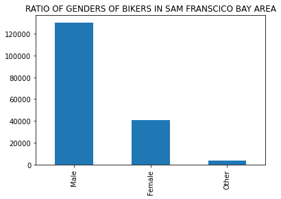

```python
# Visualization
new_df.member_gender.value_counts().plot.bar(title='RATIO OF GENDERS OF BIKERS IN SAM FRANSCICO BAY AREA');
```

# Observation

- Male have the highest ratio of cyclist
- Female have the second most highest Ratio

# Question

- What are the user type of bikers as they are registed in the database

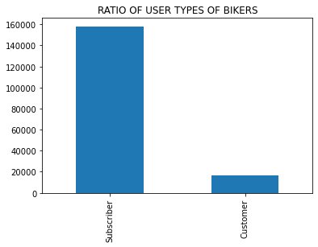

```python
# VISUALIZATION
new_df.user_type.value_counts().plot.bar(title= 'RATIO OF USER TYPES OF BIKERS');
```

# OBSERVATION

- Suscribers made up of over 70% of bikers ecosystem in San Fransisco Bay area

# Question

- What are the age groups of bikers

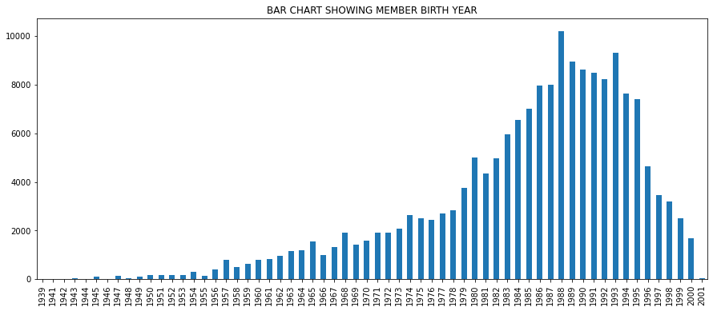

```python
# VISUALIZATION
new_df['member_birth_year'].value_counts().sort_index().plot.bar(figsize= (15,6), title='BAR CHART SHOWING MEMBER BIRTH YEAR');
```

# Observation

- 1988 has the highest ratio and 1944 has the lowest bikers.
- This is understandable because people born in 1944 doesnt have much vigor as people born in 1988

# Questions

- Do bikers share trips?

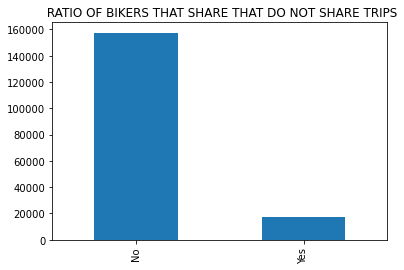

```python
# Visualization
new_df.bike_share_for_all_trip.value_counts().plot.bar(title= ' RATIO OF BIKERS THAT SHARE THAT DO NOT SHARE TRIPS');
```

# Observation

- Higher percentage of bikers do not share trips

```python
new_df.duration_sec.value_counts()
```

```
272     308
323     284
305     282
369     280
274     276
       ...
4080      1
2827      1
8199      1
3993      1
2822      1
Name: duration_sec, Length: 4429, dtype: int64
```

```python
new_df.sample(10)
```

|  | duration_sec | start_time | end_time | start_station_id | start_station_name | start_station_latitude | start_station_longitude | end_station_id | end_station_name | end_station_latitude | end_station_longitude | bike_id | user_type | member_birth_year | member_gender | bike_share_for_all_trip |
| --- | --- | --- | --- | --- | --- | --- | --- | --- | --- | --- | --- | --- | --- | --- | --- | --- |
| 49804 | 2065 | 2019-02-21 20:00:16.306 | 2019-02-21 20:34:42.091 | 7 | Frank H Ogawa Plaza | 37.804562 | -122.271738 | 164 | Isabella St at San Pablo Ave | 37.814988 | -122.274844 | 6034 | Subscriber | 1991 | Male | Yes |
| 32394 | 712 | 2019-02-24 14:27:53.627 | 2019-02-24 14:39:45.851 | 131 | 22nd St at Dolores St | 37.755000 | -122.425728 | 73 | Pierce St at Haight St | 37.771793 | -122.433708 | 4383 | Subscriber | 1988 | Male | No |
| 154654 | 557 | 2019-02-06 09:29:54.606 | 2019-02-06 09:39:12.419 | 253 | Haste St at College Ave | 37.866418 | -122.253799 | 246 | Berkeley Civic Center | 37.869060 | -122.270556 | 3726 | Subscriber | 1996 | Male | No |
| 256 | 524 | 2019-02-28 22:07:25.185 | 2019-02-28 22:16:09.617 | 110 | 17th & Folsom Street Park (17th St at Folsom St) | 37.763708 | -122.415204 | 61 | Howard St at 8th St | 37.776513 | -122.411306 | 1891 | Subscriber | 1988 | Female | No |
| 74140 | 990 | 2019-02-19 11:17:01.952 | 2019-02-19 11:33:32.145 | 106 | Sanchez St at 17th St | 37.763242 | -122.430675 | 355 | 23rd St at Tennessee St | 37.755367 | -122.388795 | 5575 | Subscriber | 1975 | Male | No |
| 109710 | 512 | 2019-02-12 18:41:28.592 | 2019-02-12 18:50:00.643 | 7 | Frank H Ogawa Plaza | 37.804562 | -122.271738 | 200 | 2nd Ave at E 18th St | 37.800214 | -122.253810 | 1449 | Subscriber | 1984 | Other | No |
| 108735 | 314 | 2019-02-13 01:01:28.339 | 2019-02-13 01:06:42.909 | 243 | Bancroft Way at College Ave | 37.869360 | -122.254337 | 266 | Parker St at Fulton St | 37.862464 | -122.264791 | 1440 | Customer | 1995 | Other | No |
| 92194 | 741 | 2019-02-15 19:37:05.877 | 2019-02-15 19:49:27.588 | 44 | Civic Center/UN Plaza BART Station (Market St ... | 37.781074 | -122.411738 | 98 | Valencia St at 16th St | 37.765052 | -122.421866 | 6565 | Subscriber | 2000 | Male | No |
| 108833 | 518 | 2019-02-12 21:44:42.499 | 2019-02-12 21:53:21.103 | 370 | Jones St at Post St | 37.787327 | -122.413278 | 31 | Raymond Kimbell Playground | 37.783813 | -122.434559 | 6220 | Subscriber | 1994 | Male | No |
| 15320 | 763 | 2019-02-27 09:33:42.017 | 2019-02-27 09:46:25.340 | 141 | Valencia St at Cesar Chavez St | 37.747998 | -122.420219 | 89 | Division St at Potrero Ave | 37.769218 | -122.407646 | 619 | Subscriber | 1993 | Male | No |

# Question

How are genders distributed across user type

```python
gen_user= pd.crosstab(new_df['user_type'], new_df['member_gender'])
gen_user
```

| member_gender user_type | Female | Male | Other |
| --- | --- | --- | --- |
| Customer | 4622 | 11487 | 448 |
| Subscriber | 36149 | 118858 | 3196 |

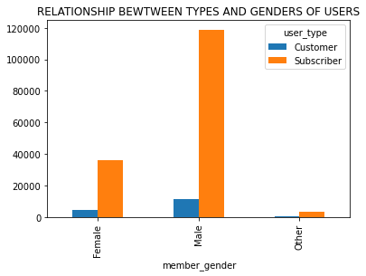

```python
# Visualization
gen_user.T.plot.bar(title='RELATIONSHIP BEWTWEEN TYPES AND GENDERS OF USERS');
```

# Observation

- Male gender subscriber has the largest distribution
- Other gender customer has the lowest distribution
- Almost bikers are suscribers

```python
# Create age column
new_df['member_age']= 2019- new_df['member_birth_year']
```

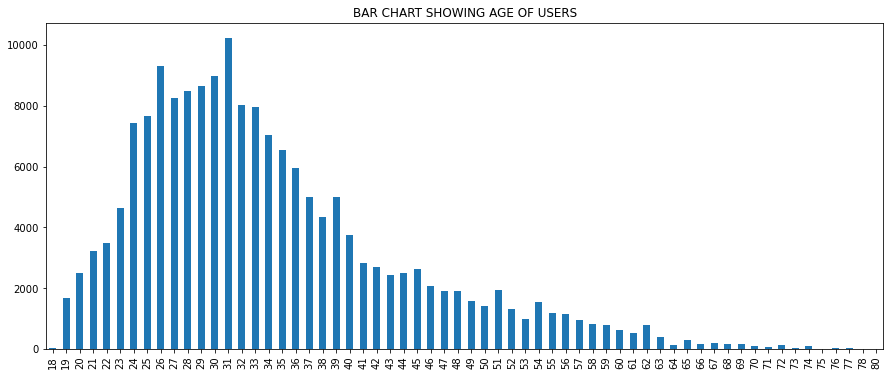

```python
# Visualization
new_df['member_age'].value_counts().sort_index().plot.bar(figsize= (15,6),title='BAR CHART SHOWING AGE OF USERS');
```

```python
new_df.info()
```

```
<class 'pandas.core.frame.DataFrame'>
Int64Index: 174760 entries, 0 to 183411
Data columns (total 17 columns):
 #   Column                   Non-Null Count   Dtype
---  ------                   --------------   -----
 0   duration_sec             174760 non-null  int64
 1   start_time               174760 non-null  datetime64[ns]
 2   end_time                 174760 non-null  datetime64[ns]
 3   start_station_id         174760 non-null  int32
 4   start_station_name       174760 non-null  object
 5   start_station_latitude   174760 non-null  float64
 6   start_station_longitude  174760 non-null  float64
 7   end_station_id           174760 non-null  int32
 8   end_station_name         174760 non-null  object
 9   end_station_latitude     174760 non-null  float64
 10  end_station_longitude    174760 non-null  float64
 11  bike_id                  174760 non-null  int64
 12  user_type                174760 non-null  category
 13  member_birth_year        174760 non-null  int32
 14  member_gender            174760 non-null  category
 15  bike_share_for_all_trip  174760 non-null  object
 16  member_age               174760 non-null  int32
dtypes: category(2), datetime64[ns](2), float64(4), int32(4), int64(2), object(3)
memory usage: 19.0+ MB
```

# Question

- What is the relationship between Duration seconds and member age

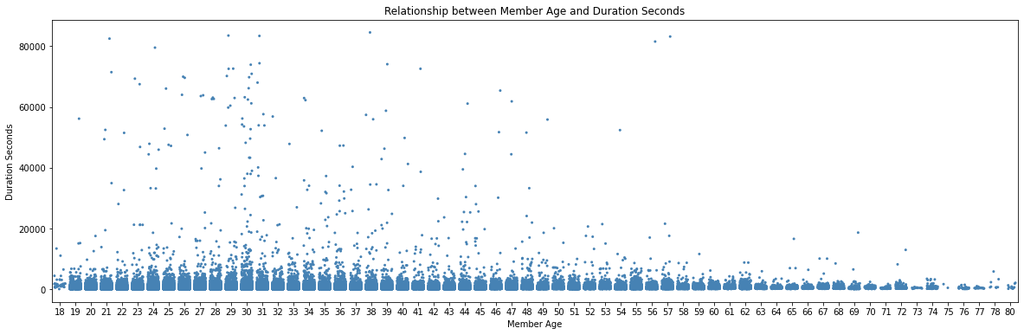

```python
# Visualization
# write a function to avoid repeating codes
def scatter_plot(data, x, y):
    fig, ax= plt.subplots(figsize=(20,6))
    sns.stripplot(data= data, y=y,x=x, jitter= 0.35, color='steelblue', size=3)
    plt.title( 'Relationship between Member Age and Duration Seconds')
    plt.ylabel('Duration Seconds')
    plt.xlabel('Member Age');

scatter_plot(data= new_df, y= 'duration_sec', x= 'member_age')
```

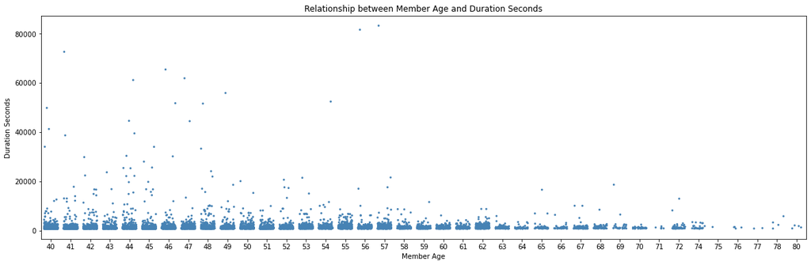

```python
# Remove outliers so as to capture all value
quantile= new_df.query('duration_sec> duration_sec.quantile(0.75) and member_age>member_age.quantile(0.75)')
scatter_plot(data= quantile, y= 'duration_sec', x= 'member_age')
```

# OBSERVATION

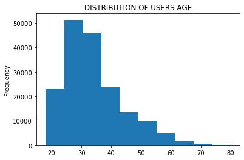

```python
# Visualization
new_df.member_age.plot.hist(title= 'DISTRIBUTION OF USERS AGE');
```

# OBSERVATION

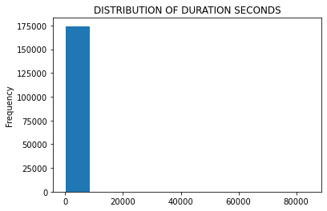

```python
new_df.duration_sec.plot.hist(title= 'DISTRIBUTION OF DURATION SECONDS');
```

# OBSERVATION

- the duration seconds column is skewed to the right

# Question

- What is the relationship between the gender of members and duration seconds

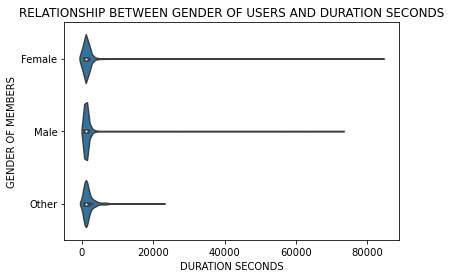

```python
# Visualization
sns.violinplot(data= quantile, y= 'member_gender', x= 'duration_sec', color=sns.color_palette()[0])
plt.title('RELATIONSHIP BETWEEN GENDER OF USERS AND DURATION SECONDS')
plt.ylabel('GENDER OF MEMBERS')
plt.xlabel('DURATION SECONDS');
```

# Observations

- Female has the highest range of duration seconds
- Male has the largest distribution of Duration seconds

# Question

- What is the correlation of the dataset

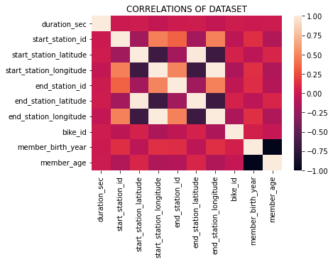

```python
# Visualization
sns.heatmap(new_df.corr())
plt.title('CORRELATIONS OF DATASET');
```

```python
new_df.info()
```

```
<class 'pandas.core.frame.DataFrame'>
Int64Index: 174760 entries, 0 to 183411
Data columns (total 17 columns):
 #   Column                   Non-Null Count   Dtype
---  ------                   --------------   -----
 0   duration_sec             174760 non-null  int64
 1   start_time               174760 non-null  datetime64[ns]
 2   end_time                 174760 non-null  datetime64[ns]
 3   start_station_id         174760 non-null  int32
 4   start_station_name       174760 non-null  object
 5   start_station_latitude   174760 non-null  float64
 6   start_station_longitude  174760 non-null  float64
 7   end_station_id           174760 non-null  int32
 8   end_station_name         174760 non-null  object
 9   end_station_latitude     174760 non-null  float64
 10  end_station_longitude    174760 non-null  float64
 11  bike_id                  174760 non-null  int64
 12  user_type                174760 non-null  category
 13  member_birth_year        174760 non-null  int32
 14  member_gender            174760 non-null  category
 15  bike_share_for_all_trip  174760 non-null  object
 16  member_age               174760 non-null  int32
dtypes: category(2), datetime64[ns](2), float64(4), int32(4), int64(2), object(3)
memory usage: 23.0+ MB
```

# Question

- what is the relationship between member age, duration seconds and member_gender

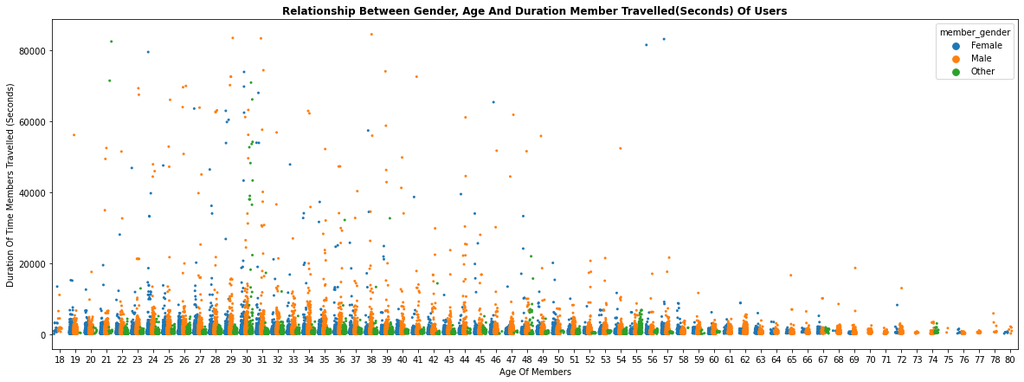

```python
# Create a funtion to avoid repeating codes
def scatter_vis(data, x,y, hue):
    plt.figure(figsize= (20,7))
    plot= sns.stripplot(data= new_df,
                        x=x,
                        y= y,
                        hue= hue,
                        size= 3, jitter= 0.35, dodge= True )
    plt.xlabel('AGE OF MEMBERS'.title())
    plt.ylabel('DURATION OF TIME MEMBERS TRAVELLED (SECONDS)'.title())
    plt.title('RELATIONSHIP BETWEEN GENDER, AGE AND DURATION MEMBER TRAVELLED(SECONDS) OF USERS'.title(), weight= 'bold');

scatter_vis(data= new_df, x= 'member_age', y= 'duration_sec', hue= 'member_gender')
```

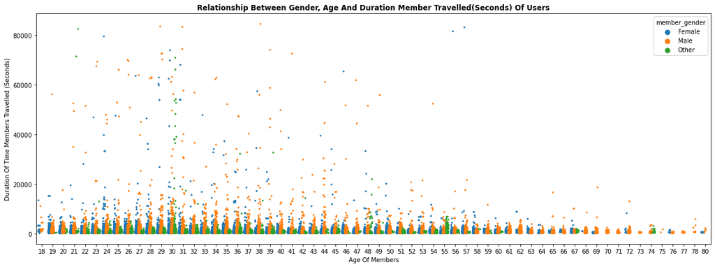

```python
# remove outliers so as to get a better insight on the plot
data= new_df.query('duration_sec<duration_sec.quantile(0.99)')
scatter_vis(data= data, x= 'member_age', y= 'duration_sec', hue= 'member_gender')
```

# Observations

- Male has the largest distribution of data
- Female has the highest distribution of data
- Bikers that are between the age of 29-31 travelled for longer duration (seconds) as compared to bikers of other age group

```python
new_df.head()
```

|  | duration_sec | start_time | end_time | start_station_id | start_station_name | start_station_latitude | start_station_longitude | end_station_id | end_station_name | end_station_latitude | end_station_longitude | bike_id | user_type | member_birth_year | member_gender | bike_share_for_all_trip | member_age |
| --- | --- | --- | --- | --- | --- | --- | --- | --- | --- | --- | --- | --- | --- | --- | --- | --- | --- |
| 0 | 52185 | 2019-02-28 17:32:10.145 | 2019-03-01 08:01:55.975 | 21 | Montgomery St BART Station (Market St at 2nd St) | 37.789625 | -122.400811 | 13 | Commercial St at Montgomery St | 37.794231 | -122.402923 | 4902 | Customer | 1984 | Male | No | 35 |
| 2 | 61854 | 2019-02-28 12:13:13.218 | 2019-03-01 05:24:08.146 | 86 | Market St at Dolores St | 37.769305 | -122.426826 | 3 | Powell St BART Station (Market St at 4th St) | 37.786375 | -122.404904 | 5905 | Customer | 1972 | Male | No | 47 |
| 3 | 36490 | 2019-02-28 17:54:26.010 | 2019-03-01 04:02:36.842 | 375 | Grove St at Masonic Ave | 37.774836 | -122.446546 | 70 | Central Ave at Fell St | 37.773311 | -122.444293 | 6638 | Subscriber | 1989 | Other | No | 30 |
| 4 | 1585 | 2019-02-28 23:54:18.549 | 2019-03-01 00:20:44.074 | 7 | Frank H Ogawa Plaza | 37.804562 | -122.271738 | 222 | 10th Ave at E 15th St | 37.792714 | -122.248780 | 4898 | Subscriber | 1974 | Male | Yes | 45 |
| 5 | 1793 | 2019-02-28 23:49:58.632 | 2019-03-01 00:19:51.760 | 93 | 4th St at Mission Bay Blvd S | 37.770407 | -122.391198 | 323 | Broadway at Kearny | 37.798014 | -122.405950 | 5200 | Subscriber | 1959 | Male | No | 60 |

```python
# Split datetime time into different column
new_df['time_started']= pd.to_datetime(new_df['start_time']).dt.time
```

```python
new_df.head()
```

|  | duration_sec | start_time | end_time | start_station_id | start_station_name | start_station_latitude | start_station_longitude | end_station_id | end_station_name | end_station_latitude | end_station_longitude | bike_id | user_type | member_birth_year | member_gender | bike_share_for_all_trip | member_age | time_started |
| --- | --- | --- | --- | --- | --- | --- | --- | --- | --- | --- | --- | --- | --- | --- | --- | --- | --- | --- |
| 0 | 52185 | 2019-02-28 17:32:10.145 | 2019-03-01 08:01:55.975 | 21 | Montgomery St BART Station (Market St at 2nd St) | 37.789625 | -122.400811 | 13 | Commercial St at Montgomery St | 37.794231 | -122.402923 | 4902 | Customer | 1984 | Male | No | 35 | 17:32:10.145000 |
| 2 | 61854 | 2019-02-28 12:13:13.218 | 2019-03-01 05:24:08.146 | 86 | Market St at Dolores St | 37.769305 | -122.426826 | 3 | Powell St BART Station (Market St at 4th St) | 37.786375 | -122.404904 | 5905 | Customer | 1972 | Male | No | 47 | 12:13:13.218000 |
| 3 | 36490 | 2019-02-28 17:54:26.010 | 2019-03-01 04:02:36.842 | 375 | Grove St at Masonic Ave | 37.774836 | -122.446546 | 70 | Central Ave at Fell St | 37.773311 | -122.444293 | 6638 | Subscriber | 1989 | Other | No | 30 | 17:54:26.010000 |
| 4 | 1585 | 2019-02-28 23:54:18.549 | 2019-03-01 00:20:44.074 | 7 | Frank H Ogawa Plaza | 37.804562 | -122.271738 | 222 | 10th Ave at E 15th St | 37.792714 | -122.248780 | 4898 | Subscriber | 1974 | Male | Yes | 45 | 23:54:18.549000 |
| 5 | 1793 | 2019-02-28 23:49:58.632 | 2019-03-01 00:19:51.760 | 93 | 4th St at Mission Bay Blvd S | 37.770407 | -122.391198 | 323 | Broadway at Kearny | 37.798014 | -122.405950 | 5200 | Subscriber | 1959 | Male | No | 60 | 23:49:58.632000 |

```python
new_df.info()
```

```
<class 'pandas.core.frame.DataFrame'>
Int64Index: 174760 entries, 0 to 183411
Data columns (total 18 columns):
 #   Column                   Non-Null Count   Dtype
---  ------                   --------------   -----
 0   duration_sec             174760 non-null  int64
 1   start_time               174760 non-null  datetime64[ns]
 2   end_time                 174760 non-null  datetime64[ns]
 3   start_station_id         174760 non-null  int32
 4   start_station_name       174760 non-null  object
 5   start_station_latitude   174760 non-null  float64
 6   start_station_longitude  174760 non-null  float64
 7   end_station_id           174760 non-null  int32
 8   end_station_name         174760 non-null  object
 9   end_station_latitude     174760 non-null  float64
 10  end_station_longitude    174760 non-null  float64
 11  bike_id                  174760 non-null  int64
 12  user_type                174760 non-null  category
 13  member_birth_year        174760 non-null  int32
 14  member_gender            174760 non-null  category
 15  bike_share_for_all_trip  174760 non-null  object
 16  member_age               174760 non-null  int32
 17  time_started             174760 non-null  object
dtypes: category(2), datetime64[ns](2), float64(4), int32(4), int64(2), object(4)
memory usage: 24.4+ MB
```

```python
# Turn the time started into parts of day category
item= []
for items in new_df['time_started']:
    hour= items.hour
    if hour >=5 and hour < 12:
        item.append('morning')
    elif hour >= 12 and hour < 17:
        item.append('afternoon')
    elif hour >= 17 and hour < 21:
        item.append('evening')
    else:
        item.append('night')
```

```python
# create part of the day column
new_df['part_of_day']= item
```

```python
new_df.sample(6)
```

|  | duration_sec | start_time | end_time | start_station_id | start_station_name | start_station_latitude | start_station_longitude | end_station_id | end_station_name | end_station_latitude | end_station_longitude | bike_id | user_type | member_birth_year | member_gender | bike_share_for_all_trip | member_age | time_started | part_of_day |
| --- | --- | --- | --- | --- | --- | --- | --- | --- | --- | --- | --- | --- | --- | --- | --- | --- | --- | --- | --- |
| 80656 | 1243 | 2019-02-18 14:56:09.816 | 2019-02-18 15:16:53.634 | 100 | Bryant St at 15th St | 37.767100 | -122.410662 | 365 | Turk St at Fillmore St | 37.780450 | -122.431946 | 3129 | Subscriber | 1977 | Male | No | 42 | 14:56:09.816000 | afternoon |
| 136186 | 299 | 2019-02-08 10:24:42.632 | 2019-02-08 10:29:41.712 | 130 | 22nd St Caltrain Station | 37.757288 | -122.392051 | 104 | 4th St at 16th St | 37.767045 | -122.390833 | 370 | Subscriber | 1988 | Female | No | 31 | 10:24:42.632000 | morning |
| 150778 | 1547 | 2019-02-06 17:32:47.481 | 2019-02-06 17:58:34.699 | 247 | Fulton St at Bancroft Way | 37.867789 | -122.265896 | 178 | Broadway at 30th St | 37.819381 | -122.261928 | 1648 | Subscriber | 1993 | Female | No | 26 | 17:32:47.481000 | evening |
| 100155 | 689 | 2019-02-14 18:35:06.580 | 2019-02-14 18:46:35.769 | 130 | 22nd St Caltrain Station | 37.757288 | -122.392051 | 139 | Garfield Square (25th St at Harrison St) | 37.751017 | -122.411901 | 6285 | Subscriber | 1994 | Female | No | 25 | 18:35:06.580000 | evening |
| 11556 | 731 | 2019-02-27 18:24:31.938 | 2019-02-27 18:36:43.219 | 11 | Davis St at Jackson St | 37.797280 | -122.398436 | 93 | 4th St at Mission Bay Blvd S | 37.770407 | -122.391198 | 6203 | Subscriber | 1994 | Male | No | 25 | 18:24:31.938000 | evening |
| 97092 | 486 | 2019-02-15 09:19:24.847 | 2019-02-15 09:27:30.939 | 75 | Market St at Franklin St | 37.773793 | -122.421239 | 3 | Powell St BART Station (Market St at 4th St) | 37.786375 | -122.404904 | 498 | Subscriber | 1988 | Male | No | 31 | 09:19:24.847000 | morning |

```python
new_df.part_of_day.value_counts()
```

```
morning      65206
evening      52624
afternoon    46003
night        10927
Name: part_of_day, dtype: int64
```

```python
new_df[new_df.part_of_day=='night'].sample(4)
```

|  | duration_sec | start_time | end_time | start_station_id | start_station_name | start_station_latitude | start_station_longitude | end_station_id | end_station_name | end_station_latitude | end_station_longitude | bike_id | user_type | member_birth_year | member_gender | bike_share_for_all_trip | member_age | time_started | part_of_day |
| --- | --- | --- | --- | --- | --- | --- | --- | --- | --- | --- | --- | --- | --- | --- | --- | --- | --- | --- | --- |
| 117338 | 1392 | 2019-02-11 22:11:02.585 | 2019-02-11 22:34:14.839 | 371 | Lombard St at Columbus Ave | 37.802746 | -122.413579 | 10 | Washington St at Kearny St | 37.795393 | -122.404770 | 5188 | Subscriber | 1988 | Male | No | 31 | 22:11:02.585000 | night |
| 10035 | 799 | 2019-02-27 22:01:43.573 | 2019-02-27 22:15:03.184 | 245 | Downtown Berkeley BART | 37.870139 | -122.268422 | 210 | 45th St at Manila | 37.833294 | -122.256224 | 2372 | Subscriber | 1983 | Male | No | 36 | 22:01:43.573000 | night |
| 40229 | 450 | 2019-02-22 21:45:37.723 | 2019-02-22 21:53:07.936 | 223 | 16th St Mission BART Station 2 | 37.764765 | -122.420091 | 125 | 20th St at Bryant St | 37.759200 | -122.409851 | 2241 | Subscriber | 1985 | Male | No | 34 | 21:45:37.723000 | night |
| 34650 | 1095 | 2019-02-23 22:07:03.563 | 2019-02-23 22:25:18.630 | 194 | Lakeshore Ave at Trestle Glen Rd | 37.811081 | -122.243268 | 193 | Grand Ave at Santa Clara Ave | 37.812744 | -122.247215 | 6190 | Subscriber | 1987 | Male | No | 32 | 22:07:03.563000 | night |

# Question

- What part of the day do bikers ride the most?

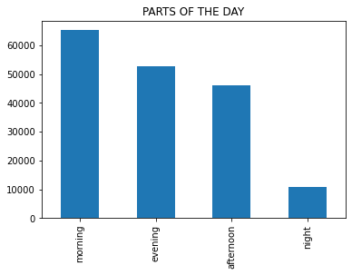

```python
# Visualization
new_df.part_of_day.value_counts().plot.bar(title= 'PARTS OF THE DAY');
```

# Observation

- Bikers ride most in the morning, this could be as a result of the mild weather

# Question

- What is the relationship between Member gender and Part of the day that bikers ride

```python
a= pd.crosstab(new_df['member_gender'], new_df['part_of_day'])
a
```

| part_of_day member_gender | afternoon | evening | morning | night |
| --- | --- | --- | --- | --- |
| Female | 10808 | 11908 | 16297 | 1758 |
| Male | 34165 | 39639 | 47675 | 8866 |
| Other | 1030 | 1077 | 1234 | 303 |

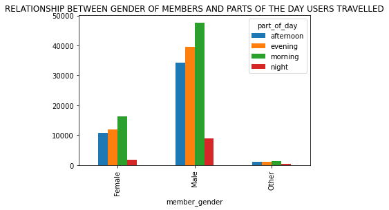

```python
# Visualization
a.plot.bar(title='RELATIONSHIP BETWEEN GENDER OF MEMBERS AND PARTS OF THE DAY USERS TRAVELLED');
```

# Observation

- All genders ride more in the morning and lesser at night

# Question

- What is the relationship between user types and part of the day

```python
# check how part of day and user types columns correpond wtheach other.
# How many users ride at diffferent time of the day
b=pd.crosstab(new_df['part_of_day'], new_df['user_type'])
b
```

| user_type part_of_day | Customer | Subscriber |
| --- | --- | --- |
| afternoon | 5821 | 40182 |
| evening | 4422 | 48202 |
| morning | 5394 | 59812 |
| night | 920 | 10007 |

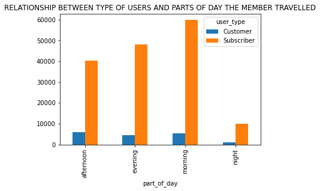

```python
# Visualization
b.plot.bar(title= 'RELATIONSHIP BETWEEN TYPE OF USERS AND PARTS OF DAY THE MEMBER TRAVELLED');
```

# Observation

- Customers doesnt use the system as much as suscribers does even at all time of the day

# Question

- Whate is the relationship between how long a biker travelled and when they travelled

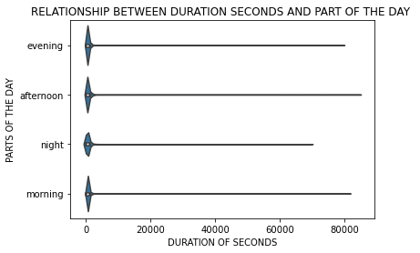

```python
# Visualization
sns.violinplot(data= new_df, y= 'part_of_day', x= 'duration_sec', color=sns.color_palette()[0])
plt.ylabel('PARTS OF THE DAY')
plt.xlabel('DURATION OF SECONDS')
plt.title('RELATIONSHIP BETWEEN DURATION SECONDS AND PART OF THE DAY ');
```

# Observation

# SUMMARY

The dataset used for this project was gotten from Ford Gobike Sysytem Data. This dataset includes information about individual rides made in bike sharing system covering the greater San Fransisco Bay Area. Excessive data assessment, cleaning and data visualization was done so as to get insights from the data. Some of the insights gotten includes:

```python
# To download the slide into an html file
# !jupyter nbconvert Data_visualization_project.ipynb --to slides --post serve --no-input --no-prompt
```